# 第9回 買う割合を、記録から当てる

経済プログラミング特論II

第9回・開店 5 日目

買う割合を、記録から当てる

1 回売れた値段で、次も決めてよいか

経済プログラミング特論II

第9回・開店 5 日目 — Topic01

購入確率を決めて、乱数で売る

売れるかは、隠れた買う割合が決める

## うちの店と、店長を育てる道

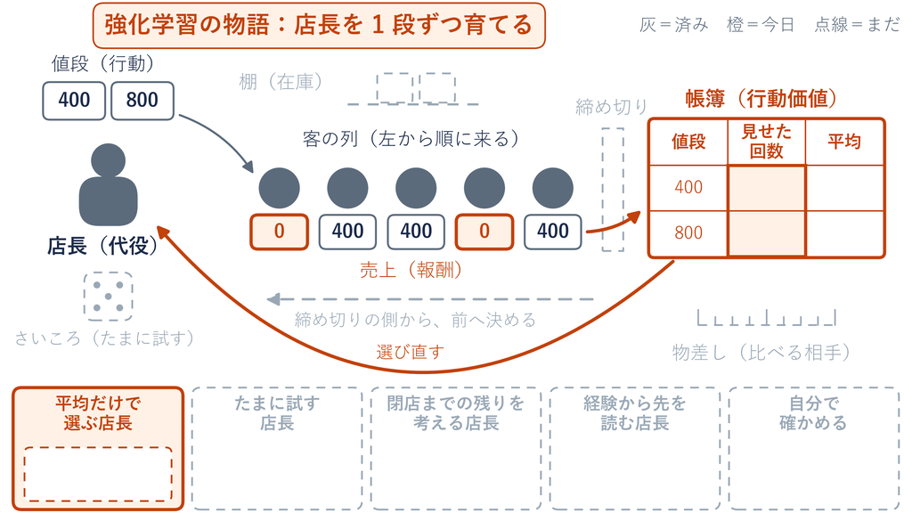

## 前の回までと今日の相談

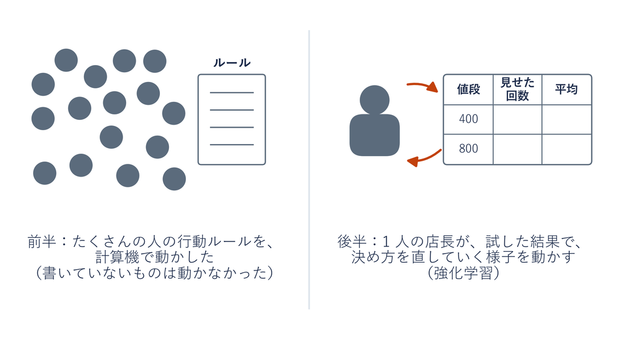

**今日の相談：1 回売れた値段で、次も決めてよいか**

前に作った注意の一覧（比べる相手と測る数を先に決める・  
揺れより大きいかで読む など）を、今度は店で使う

## 今日の道のり

1

店を開く

実習：実行 店を開く準備

実習：写経 値段ごとの集計

演習 1 800円から始める6人

2

引き直す

実習：写経 100 本の引き直し

演習 2 各3回の引き直し

3

割合を当てる

実習：写経 帳簿と当てた割合

演習 3 seed 2 で当てる

4

確かめ直す

実習：写経 1 greedy 関数

実習：写経 2 2 つの店

演習 4 100人に伸ばす

**今日のゴール**：1 回売れた値段で、次も決めてよいか？  
記録を数え、引き直し、確かめ直して答える

作業のページの右上のカードは、ノートでやる作業の種類（写経・実行・演習）

## 800円ですぐ売れた古着の次の値付け

フリマアプリに古着を 800円で載せたら、1時間後に売れた  
→ 次の古着も 800円 → 3日売れない

**1 着目が売れたとき、どう考えればよかったか**

**①** 次の古着も、800円にする  
**②** 次は、400円に下げる  
**③** 1回だけでは、決められない

動画を止めて、①〜③から1つ選んで、少し考えてから再生

答え：**③** 1回だけでは、決められない

## ネットの店と、買う割合

手作りの品をネットで売る店。値段は 400 円か 800 円の 2 つから選ぶ

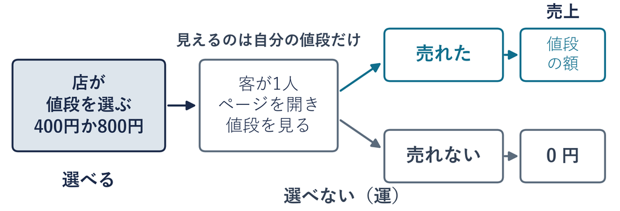

計算機の中の店の設定（私が決めた**購入確率**）  
400 円：客の **8 割**が買う ／ 800 円：客の **3 割**が買う  
ならすと 1 人あたり 400 × 0.8 ＝ **320 円** ／ 800 × 0.3 ＝ **240 円**

## seed：乱数の出発点

計算機の中の客は、乱数で作る。1 人ずつくじを引き  
400 円なら 10 本中 8 本、800 円なら 10 本中 3 本が「買う」

- **seed**：乱数の出発点の番号
- **同じ seed**：何度開いても、同じ客が同じ順に来る
- **別の seed**：同じ店に、別の日の客が来る

このあとは seed 42 の記録。どの客が買うかは、乱数で決まる

## 6 人の客の記録

記録を取るため、ページを開いた客ごとに  
400 円と 800 円を交互に見せる（金額は円）

この客は、seed 42 の乱数で作った客  
買うかどうかは 1 人ずつくじで決まる（400 円は 8 割・800 円は 3 割）

| 客 | 値札 | 売れたか | 売上 |
| --- | --- | --- | --- |
| 1 | 400 | ○ | 400 |
| 2 | 800 | ○ | 800 |
| 3 | 400 | ○ | 400 |
| 4 | 800 | ○ | 800 |
| 5 | 400 | ○ | 400 |
| 6 | 800 | × | 0 |

| 値札 | 見せた回数 | 売れた回数 | 売上の合計 |
| --- | --- | --- | --- |
| 400 | 3 | **3** | 1200 |
| 800 | 3 | 2 | **1600** |

**売れた回数は 400 円、売上の合計は 800 円が上**

1 行に、選んだ値段と  
受け取った売上を書く

## 売上の式：値段と 1・0 の掛け算

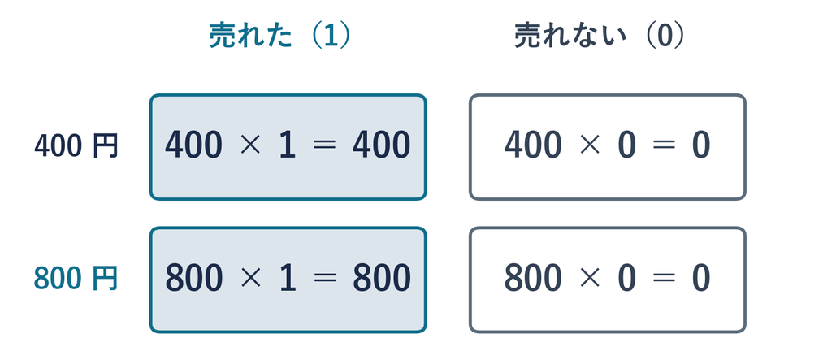

売れたら 1、売れなければ 0 を掛ける。4 つの場合しかない

## seed 42 で交互に 20回

今度は同じ並びで 20 人。最初の 6 人は、6 人の表と同じ客

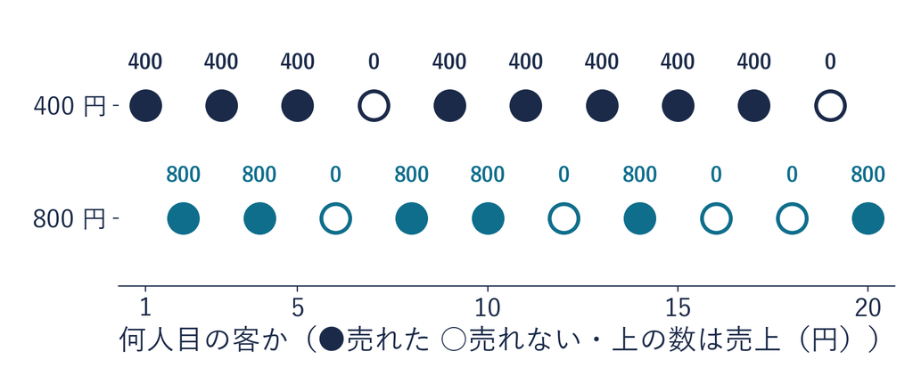

同じ 400 円でも、売れる客と売れない客がいる

## 値段ごとの集計

| 値札（円） | 見せた回数 | 売れた回数 | 売上の合計（円） |
| --- | --- | --- | --- |
| 400 | 10 | **8** | 3200 |
| 800 | 10 | 6 | **4800** |

売れた回数は 400 円が多い。売上の合計は 800 円が多い

## 数え方による逆転

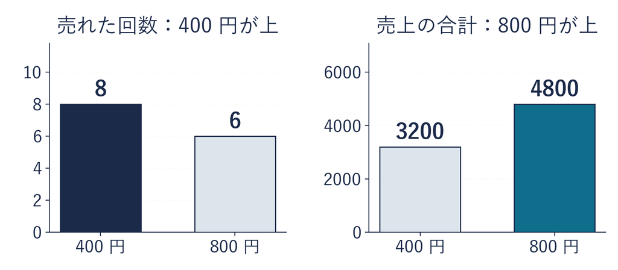

同じ20回の記録なのに、何を数えるかで答えが変わる

別の店（400 円は 75%・800 円は 45% が買う）なら 1 人あたり  
400 × 0.75 ＝ **300 円** ／ 800 × 0.45 ＝ **360 円**

## 店を開く準備のセル

ここからは自分の Colab で、同じ 20 人の記録を作る

```python
# @title 準備：店を開く道具（実行するだけ。中は開かなくてよい）
```

| 道具 | 渡すもの | 返ってくるもの |
| --- | --- | --- |
| **PRICES** | なし | 値段の並び （0 番＝400 円、1 番＝800 円） |
| **visit** | 値段の番号 | 客 1 人が買えば 1、 買わなければ 0 |
| **operate** | 値段の番号の並びと seed | 1 人 1 行の記録の表 （回・値札・売れた・売上） |

店を開く道具を作るセル。▶ で 1 回実行するだけで、中は読まなくてよい

※ ノートの段 1 にある。先に、いちばん上のコードのセルを 1 回実行

## 値段ごとの集計の写経

```python
log = operate([0, 1] * 10, seed=42)   # 値札の並び（0＝400、1＝800）と seed
for p in PRICES:                      # 値札 400、次に 800
    part = log[log["値札"] == p]      # 値札が p の行だけ
    print("値札", p, " 見せた:", len(part), "回  売れた:", part["売れた"].sum(),
          " 売上:", part["売上"].sum())
```

| 行 | 部品 | 渡すもの | 返ってくるもの・起きること |
| --- | --- | --- | --- |
| 1 | **① 店を開く** | 値段の並びと seed 42 | 20 人の記録の表 log |
| 2 | **② 値段を順に** | PRICES の 400 と 800 | p に 400、次に 800 が入る |
| 3 | **③ 行を絞る** | `log["値札"] == p` | 値札の列が p の行だけの表 part |
| 4-5 | **④ 数えて表示** | `len` と `.sum()` | 見せた回数・売れた 回数・売上の 1 行 |

※ `[0, 1] * 10` ＝ 0, 1 を 10 回くり返した並び ・ `==` ＝ 等しいかどうか ・ 実行は Shift +  
Enter（Mac は Shift + return）でもよい

⏸ PAUSE 止めて $3$ 分。準備のセルを実行し、  
**＋ コード**で 5 行を写して **▶**。3200 と 4800 が出たら再生に戻る

## 演習1 並びの書き換え

p.15 の出力 10・8・3200 ／ 10・6・4800

演習 1

800 円から始める 6 人でも、数え方で分かれるか

```python
log = operate([0, 1] * 10, seed=42)   # ← ここを書き換える
```

1. **書き換える**：写経のセルは残し、**＋ コード**で足したセルに  
   同じ 5 行を写して、1 行目を `[1, 0] * 3` に
2. **予想する**：上の値段は分かれるか（分かれる／分かれない）
3. **終わり**：実行して、見せた回数が 3 と 3 の 2 行が出たら

`[1, 0] * 3` ＝ 800・400・800・400・800・400 円の 6 人。6 人の表は 400 円から始めていた

⏸ PAUSE 動画を止めて $3$ 分。2 行が出たら再生に戻る

## 演習1の答え

値札 400 見せた: 3 回 売れた: 3 売上: 1200  
値札 800 見せた: 3 回 売れた: 1 売上: 800

| 6 人の並び | 値札 400 円 | 値札 800 円 | 回数で上 | 売上で上 |
| --- | --- | --- | --- | --- |
| 400 円から （p.9） | 3・3・1200 | 3・2・1600 | 400 円 | 800 円 |
| 800 円から （演習 1） | 3・3・1200 | 3・1・800 | 400 円 | 400 円 |

値札の欄は 見せた回数・売れた回数・売上の合計（円）

答えは「分かれない」。800 円から始めた 6 人では、  
どちらで数えても 400 円が上

## 選んで、記録して、選び直す

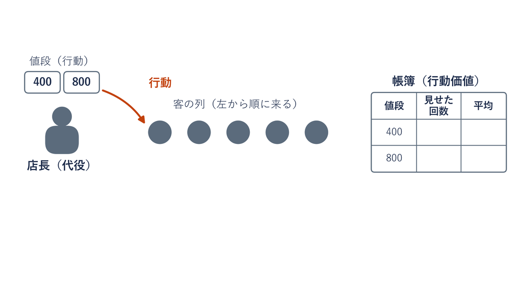

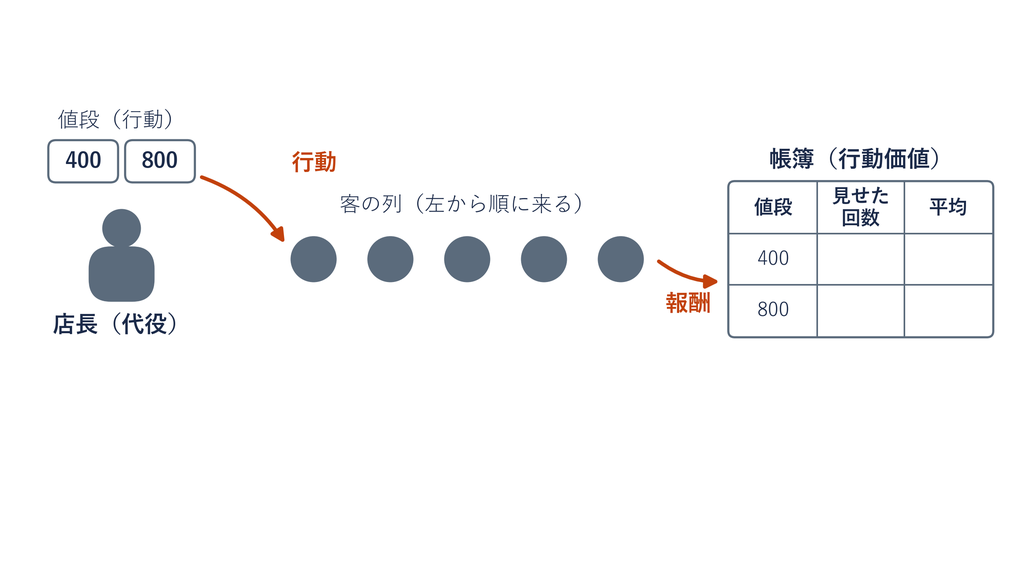

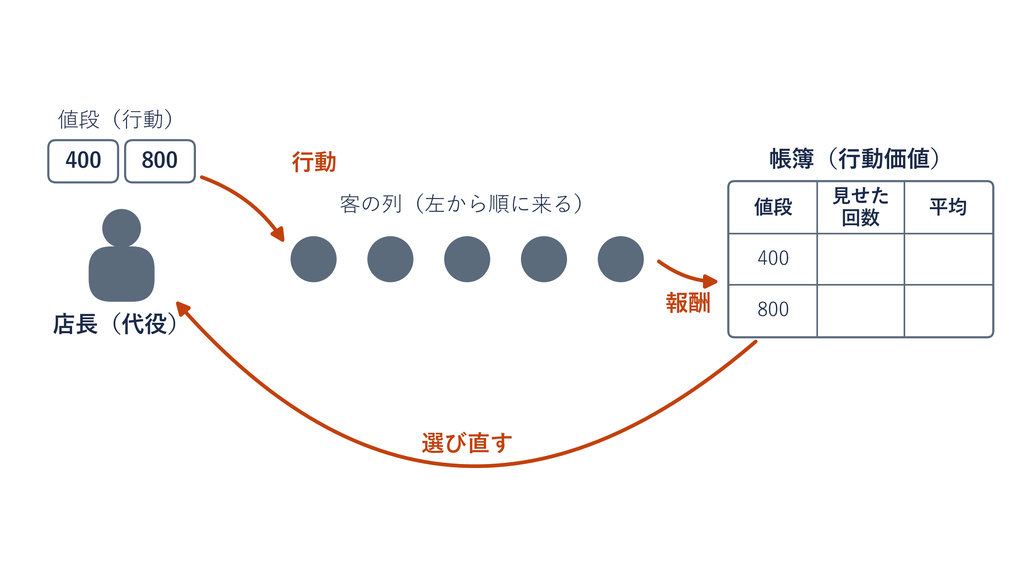

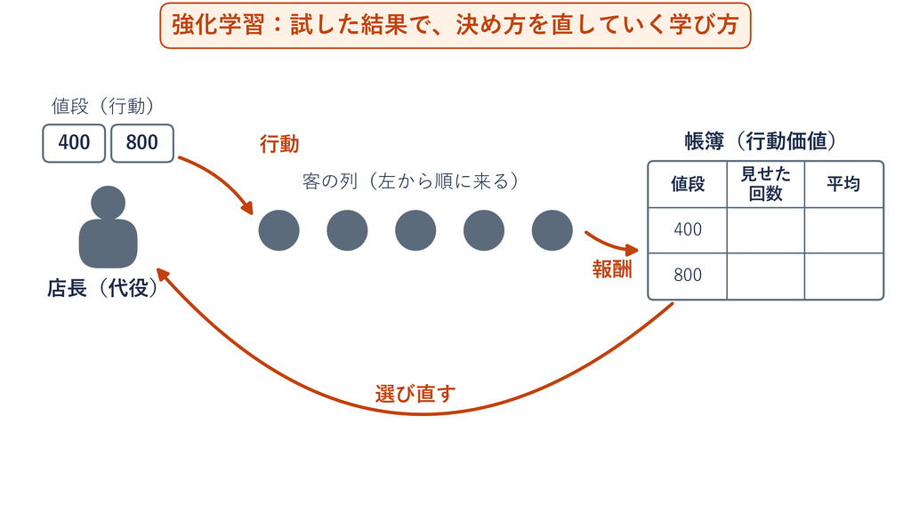

1 回売れた値段で決めると：客 1 の 400 円で止まり、輪が回らない  
（1 回の結果は運で入れ替わる。古着も 2 着目は売れなかった）

試した結果で決め方を直していく学び方の名前：**強化学習**

## まとめ

疑問 1 回売れた値段で、次も決めてよいか

回答 まだ決められない。売れるかは割合と運で決まる  
何を数えるか（売上）を先に決める

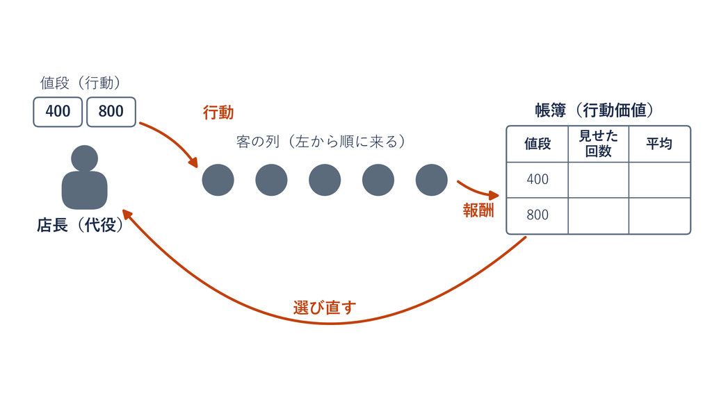

残った困りごと：設定では 400 円が有利なのに  
20 人の記録では 800 円の売上が上だった

経済プログラミング特論II

第9回・開店 5 日目 — Topic02

購入確率を動かしてみる

有利な値段は期待値で決まり、短い記録の売上は入れ替わる

## 同じ店のやり直し

同じ店で、同じ交互の並びのまま、seed だけ変えて20人  
（買う割合はトピック1 と同じ 8 割・3 割のまま）

**①** やっぱり 800 円が上になる  
**②** 400 円が上になることもある  
**③** 毎回同じ結果になる

どれになるか、見当を付けてから、小さな店で確かめる

## 6 人の店の引き直し

交互の 6 人の店を 3 回開く（seed は 42 → 42 → 1）

| 記録 | 400 | 800 | 400 | 800 | 400 | 800 | 400 円の平均 | 800 円の平均 | 上 |
| --- | --- | --- | --- | --- | --- | --- | --- | --- | --- |
| seed 42 | 400 | 800 | 400 | 800 | 400 | 0 | 400 | 約 533 | 800 |
| seed 42 | 400 | 800 | 400 | 800 | 400 | 0 | 400 | 約 533 | 800 |
| seed 1 | 400 | 0 | 400 | 800 | 400 | 0 | 400 | 約 267 | 400 |

見出しの 400・800 は、客 1〜6 に見せた値段（円）  
マスの数は売上（0 は売れなかった客）  
上は平均が高いほうの値段

同じ seed なら同じ記録。seed を変えると、  
客 1 人の違いで上の値段が入れ替わる

## 再現性

**seed を書いて残せば、同じ記録が何度でも出る**

**再現性**同じ手順と同じ条件でやり直すと、同じ結果が得られること

この店では、同じ設定・同じ seed・同じ値段の並びなら同じ記録

- **同じ seed**：何度開いても、seed 42 の20人は同じ客
- **別の seed**：同じ店に、別の日の客が来る

seed を変えることは、同じ店を別の日にやり直すこと

## くじ箱で計算する、客 1 人あたりの売上

トピック1 で決めた設定  
（400 円は 8 割・800 円は 3 割が買う）を、10 人のくじ箱にする

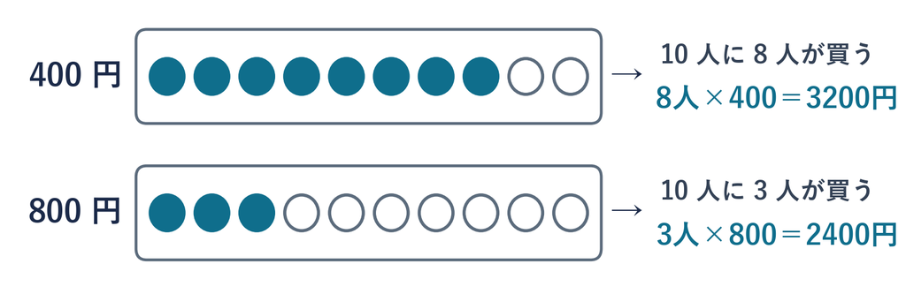

○（買わない客）も、売上 0 円の 1 人と数える 3200 ÷ 10 ＝ 320 円 ／ 2400 ÷ 10 ＝ 240 円

- **客 1 人あたりの売上の期待値**：同じ条件で大勢に見せた  
  ときの、客 1 人あたりの平均売上
- **記録の平均売上**：記録の売上の合計 ÷ その値段を見せた客の人数（記録ごとに変わる）

## seed を変えた記録

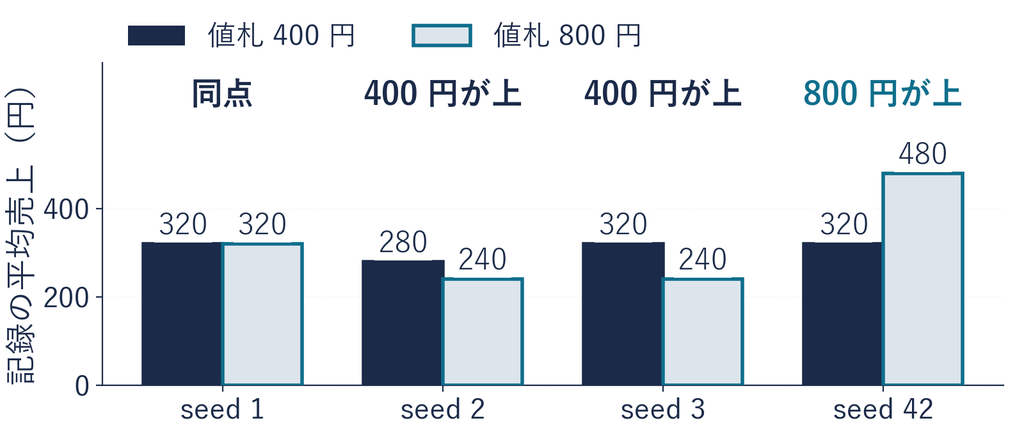

seed 1 は同点、2 と 3 は 400 円が上。800 円が上は seed 42 だけ

seed を替える ＝ 記録の上は入れ替わるが、期待値と、  
それで決まる有利な値段は変わらない

## デモ 割合と乱数を動かす

数の話

客の並び（seed）か買う割合を替えて、記録を引き直す

- **何を見るか**：差（800 円の記録の平均売上 − 400 円の記録の平均売上）  
  が 0 の右に何本あるか・期待値の差の点線がどこにあるか
- **図の意味**：差のヒストグラム（青緑＝800 円の売上が高い・灰＝同じ）・上にいまの  
  設定と客 1 人あたりの売上の期待値
- **操作**：買う割合 3 つ・各値段を客に見せる回数 3 つ・seed 4 つ・▶ で引き直す

ミッション seed を替えても、期待値の点線は動くか

※ 次のスライドへ進むときは、デモの枠の外を一度クリックしてから ← → キーを押す

[interactive chart not shown]

## 標本変動

**同じ店でも、記録を取り直すと平均は変わる**

**標本変動**同じ仕組みから標本を取り直すたびに  
標本から計算した平均などの値が変わること

標本：手元にある記録（ここでは 20 人ぶん）

- **理由**：どの客が買うかは運で決まる
- **大きさ**：記録が短いほど大きく動く

## 記録を伸ばした、計算機の中の店

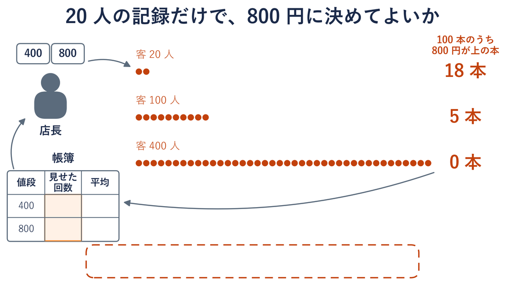

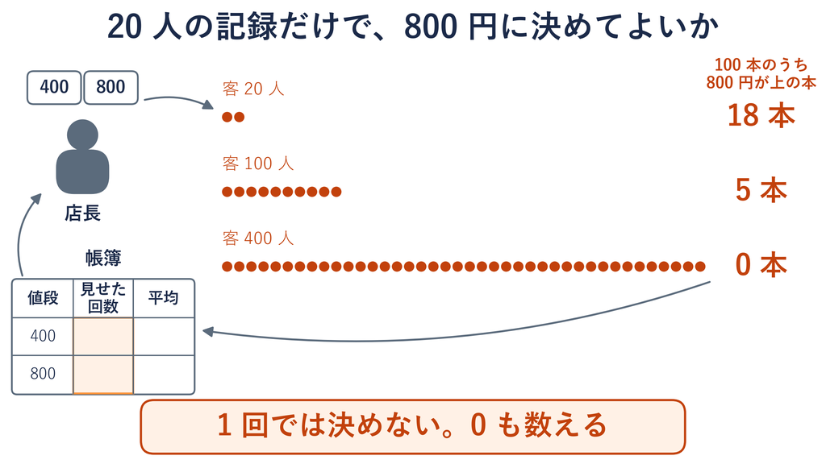

## 大数の法則

**回数を増やすほど、記録の平均は期待値に近づく**

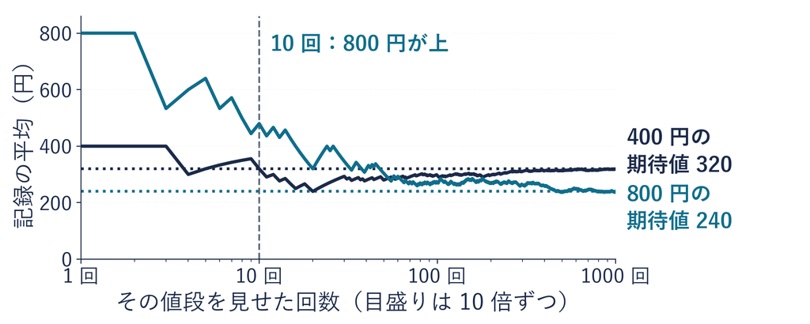

**大数の法則**同じ仕組みで回数を増やすほど、記録の平均が期待値に近づくこと

短い記録は入れ替わる（標本変動） ／ 長い記録は期待値に近づく（大数の法則）

## デモ 割合と乱数を動かす

数の話

客の並び（seed）か買う割合を替えて、記録を引き直す

- **何を見るか**：差（800 円の記録の平均売上 − 400 円の記録の平均売上）  
  が 0 の右に何本あるか・期待値の差の点線がどこにあるか
- **図の意味**：差のヒストグラム（青緑＝800 円の売上が高い・灰＝同じ）・上にいまの  
  設定と客 1 人あたりの売上の期待値
- **操作**：買う割合 3 つ・各値段を客に見せる回数 3 つ・seed 4 つ・▶ で引き直す

ミッション 買う割合を替えると、売上が高い本はどちらへ動くか

※ 次のスライドへ進むときは、デモの枠の外を一度クリックしてから ← → キーを押す

[interactive chart not shown]

## 使える場面：口コミの星

★5.0（2件）は信じにくい

2人とも満足しただけ  
次の客で大きく動く

★4.2（200件）は信じやすい

200人ぶんの平均  
1人増えてもほぼ動かない

件数の少ない平均を、件数の多い平均と同じに信じない

## 値段で分けて数える帳簿

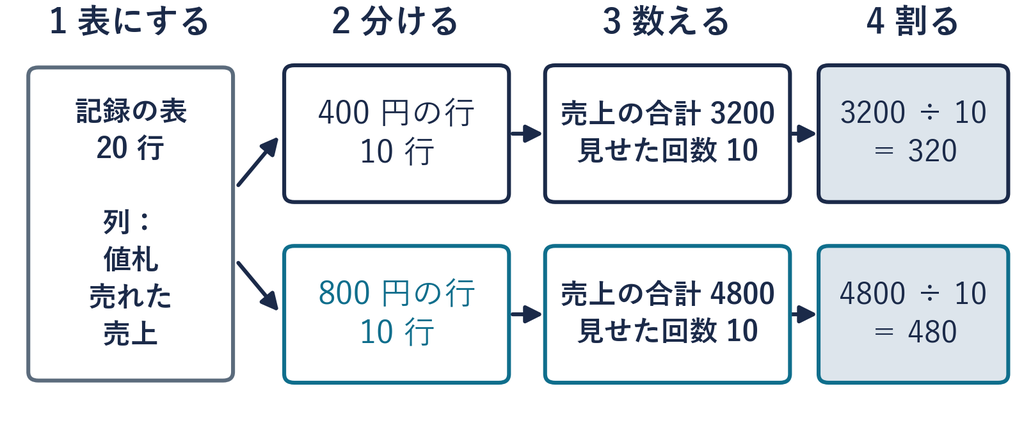

分ける → 数える → 割る。値段ごとに同じ手順

## 100 本の引き直しの写経

```python
n = 10                             # 1つの値札を見せる回数
diffs = []
for seed in range(100):            # 乱数だけ100通り引き直す
    m = operate([0, 1] * n, seed).groupby("値札")["売上"].mean()
    diffs.append(m[800] - m[400])  # 差（800 円 − 400 円）
up = sum(d > 0 for d in diffs)     # 800 円が上の本数
tie = sum(d == 0 for d in diffs)   # 同点の本数
print("800円が上:", up, " 同点:", tie, " 400円が上:", 100 - up - tie, "（100本中）")
```

| 行 | 部品 | 渡すもの | 返ってくるもの・起きること |
| --- | --- | --- | --- |
| 1-2 | **① 長さと入れ物** | `n = 10`・`[]` | 値段ごとに 10 回・空の diffs |
| 3 | **② seed を順に** | `range(100)` | seed に 0〜99 が入る |
| 4 | **③ 店を開いて平均** | `[0, 1] * n` と seed | 値段ごとの平均 m |
| 5 | **④ 差を足す** | `m[800] - m[400]` | diffs の末尾に差が 1 つ |
| 6-7 | **⑤ 数える** | `sum(d > 0 …)` | 本数（読み方は次のページ） |
| 8 | **⑥ 表示** | `100 - up - tie` | 3 つの本数の 1 行 |

⏸ PAUSE 止めて Colab で（目安 5 分） **STEP 1** **＋ コード**で 8 行を写して実行 **STEP 2** 18・11・71 を探す

## 本数を数える 1 行の読み方

前のページの 6 行目（内包表記）を展開すると、for で書ける  
4 本の差（p.27）で読む

1 行の形（内包表記）

```python
diffs = [0, -40, -80, 160]
up = sum(d > 0 for d in diffs)
```

for で書いた形

```python
diffs = [0, -40, -80, 160]
up = 0
for d in diffs:
    up = up + (d > 0)
```

| 部品 | 1 行の形（内包表記） | for で書いた形 | すること |
| --- | --- | --- | --- |
| **① 1 つずつ見る** | `for d in diffs` | `for d in diffs:` | 差を 1 つずつ d に入れる |
| **② 当てはまるか** | `d > 0` | `d > 0` | 当てはまると 1、外れると 0 （売れたら 1 と同じ） |
| **③ 足す** | `sum(…)` | `up = up + …` | 1 と 0 を全部足す＝本数 |

どちらも up は 1 で、0 より右は 4 本中 1 本（p.27 と同じ）

## 演習2 記録の長さの書き換え

p.35 の出力 18・11・71

演習 2

各 3 回にすると、800 円が上の本数は 18 より増えるか減るか

```python
n = 10                             # ← ここを書き換える
```

1. **書き換える**：写経のセルは残し、**＋ コード**で足したセルに  
   同じ 8 行を写して、1 行目を `n = 3` に
2. **確かめる**：800 円が上の本数は 18 より（増える／減る）
3. **終わり**：実行して、足すと 100 になる 3 つの本数が出たら

`n = 3` ＝ 値段ごとに 3 回、合わせて 6 人の客（6 人の店の引き直しと同じ長さ）

⏸ PAUSE 動画を止めて $3$ 分。3 つの本数が出たら再生に戻る

## 演習2の答え

| 1つの値段を見せる回数 | 800 円が上 | 同点 | 400 円が上 |
| --- | --- | --- | --- |
| 各 3 回（演習 2） | 27 | 17 | 56 |
| 各 10 回（p.35） | 18 | 11 | 71 |
| 各 200 回（p.27） | 0 | 0 | 100 |

- **答え**：増える。18 本 → 27 本
- **理由**：客 1 人の違いで、800 円の平均が 800 ÷ 3 ≈ 267 動く
- **各 10 回なら**：800 ÷ 10 ＝ 80 しか動かない

記録が短いほど、入れ替わりやすい

## まとめ

疑問 20 人の記録だけで、800 円に決めてよいか

回答 決められない。短い記録は入れ替わる  
記録を伸ばしてから決める

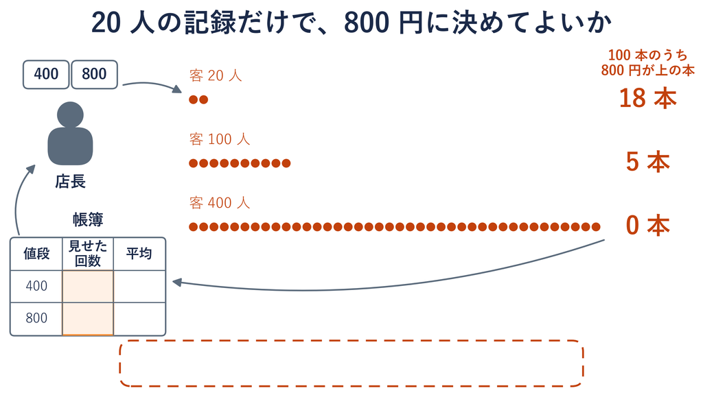

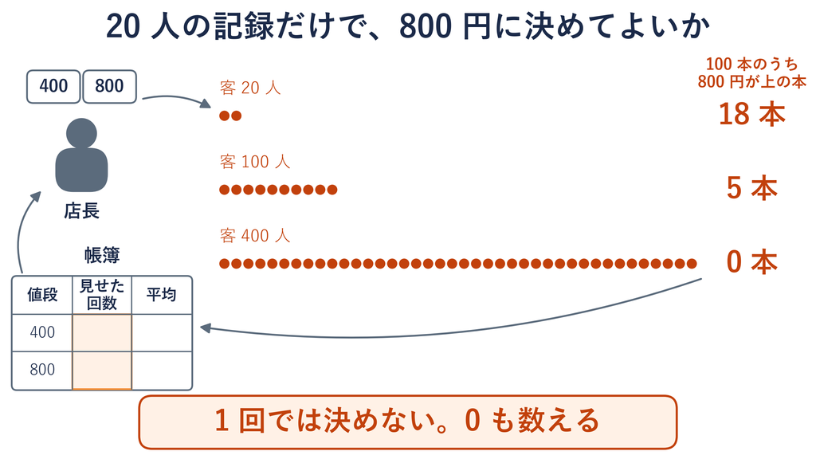

残った困りごと：本物の店では、割合を誰も知らない  
記録から割合を当てられないか

経済プログラミング特論II

第9回・開店 5 日目 — Topic03

最尤推定

記録から買う割合を当てる。短い記録の当ては外れる

## 売れた回数 ÷ 見せた回数

400 円を 5 回見せた記録。売上は 0・400・400・0・400 円

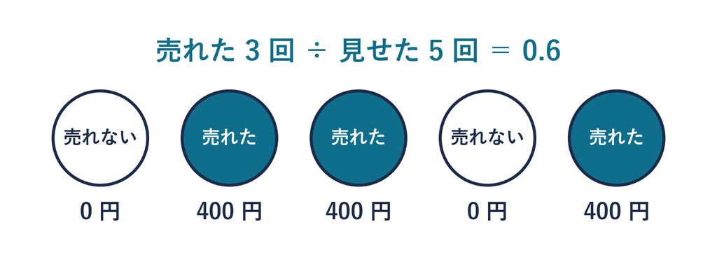

売れた 3 回 ÷ 見せた 5 回 ＝ 0.6（6 割）。売れなかった 2 回も数える

## 棒 1 本の作り方：割合を決めて記録を作る

割合を決めて、10 回見せる記録を 1 万本作る。  
10 回中 8 回売れた本を数える

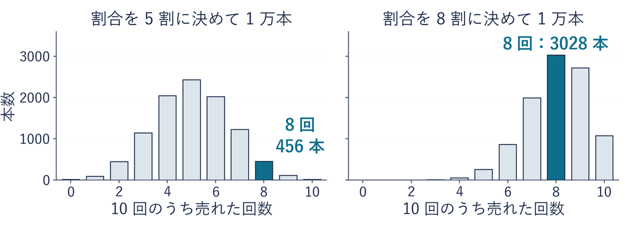

いちばん多い 8 割の 3028 本を 100 にそろえると、5 割の 456 本は 15

## どの割合なら、この記録が出やすいか

トピック1 の seed 42 の 20 人のうち、400 円を見せた 10 回では 8 回売れた

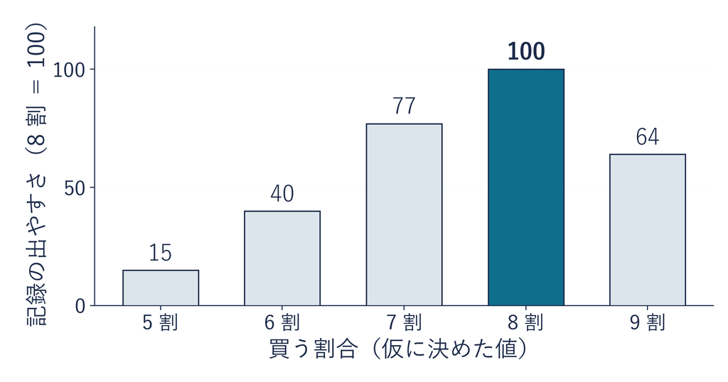

10 回中 8 回の記録がいちばん出やすいのは、割合が 8 割のとき

## 最尤推定

**記録がいちばん出やすくなる割合を、答えにする**

定義

**最尤推定**手元の記録が、いちばん出やすくなる割合を  
当てた割合にするやり方

この店では 当てた割合 ＝ 売れた回数 ÷ その値段を客に見せた回数

- **名前**：最＝いちばん・尤＝もっともらしい  
  （この記録が、いちばんありそうになる）
- **前半とのつながり**：記録に合わせて隠れた数を決める。物差しは、  
  前は平均・今度は記録の出やすさ

## seed 42 の 20 人で当てた割合

| 値札 | 見せた回数 | 売れた回数 | 当てた割合 | 当てた割合 × 値段（円） |
| --- | --- | --- | --- | --- |
| 400 | 10 | 8 | 0.8 | **320** |
| 800 | 10 | 6 | 0.6 | **480** |

帳簿の数 ＝ 当てた割合 × 値段（記録の平均売上と同じ数）

## 記録を伸ばしたときの、当てた割合

| 1 つの値段を見せる回数 | 10 回 | 50 回 | 200 回 | 設定 |
| --- | --- | --- | --- | --- |
| seed 42 の 400 円 | 0.8 | 0.7 | 0.745 | 0.8 |
| seed 42 の 800 円 | 0.6 | 0.38 | 0.335 | 0.3 |

1 本の記録では、近づくとは限らない（400 円は 0.8 → 0.7 → 0.745）

| seed 0〜99 の 100 本 | 10 回 | 50 回 | 200 回 |
| --- | --- | --- | --- |
| 400 円の当てた割合が 0.7〜0.9 に入る本 | 74 | 95 | 100 |

記録をたくさん集めると、当てた割合の外れが小さくなる

設定と比べて確かめられるのは、答えを知っている計算機の中だけ

## 帳簿の写経

```python
log = operate([0, 1] * 10, seed=42)   # 交互の 20 人に戻す
book = log.groupby("値札").agg(
    見せた回数=("売上", "size"), 売れた回数=("売れた", "sum"),
    売上合計=("売上", "sum"), 平均=("売上", "mean"))
book["当てた割合"] = book["売れた回数"] / book["見せた回数"]
print(book)
```

| 行 | 部品 | 渡すもの | 返ってくるもの・起きること |
| --- | --- | --- | --- |
| 1 | **① 店を開く** | 値段の並びと seed 42 | 20 人の記録の表 log |
| 2 | **② 値段で分ける** | `groupby("値札")` | 値札の列が同じ行のまとまり |
| 3-4 | ③ 数える （合計と平均も） | size・sum・sum・mean | 回数 2 つ・売上合計・平均 |
| 5 | **④ 割合を当てる** | 売れた回数 ÷ 見せた回数 | 当てた割合の列 |
| 6 | **⑤ 表示** | book | 値段 2 行の帳簿 |

**STEP 1** **＋ コード**でセルを足し、6 行を写して実行 **STEP 2** 当てた割合 0.8・0.6 と平均 320・480 を探す

⏸ PAUSE 止めて Colab で写して実行（目安 5 分）。帳簿が出たら再生に戻る

## 演習3 別の seed で当てる

p.47 の出力 当てた割合 0.8・0.6 ／ 平均 320・480

演習 3

seed 2 の記録でも、当てた割合 × 値段 ＝ 平均 になるか

```python
log = operate([0, 1] * 10, seed=42)   # ← ここを書き換える
```

1. **書き換える**：写経のセルは残し、**＋ コード**で足したセルに  
   同じ 6 行を写して、1 行目の seed を `2` に
2. **確かめる**：当てた割合 × 値段（暗算か電卓）  
   が、平均の列と同じ数か
3. **終わり**：帳簿が出て、400 円と 800 円の両方で掛け算を確かめたら

⏸ PAUSE 動画を止めて $3$ 分。帳簿と掛け算ができたら再生に戻る

## 演習3の答え

| 記録 | 400 円（割合・掛け算・平均） | 800 円（割合・掛け算・平均） |
| --- | --- | --- |
| seed 42（p.47） | 0.8・320・320 | 0.6・480・480 |
| seed 2（演習 3） | 0.7・280・280 | 0.3・240・240 |

どちらの seed でも、帳簿の数 ＝ 当てた割合 × 値段

seed 2 では 400 円が上。20 人の記録で当てた割合は、seed で変わる

## まとめ

疑問 割合を知らないとき、記録からどう当てるか

回答 記録がいちばん出やすくなる割合を答えにする（最尤推定）  
帳簿の数 ＝ 当てた割合 × 値段。短い記録の当ては外れる

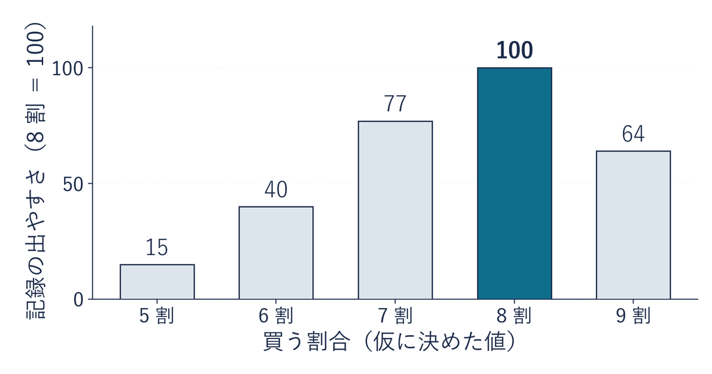

残った困りごと：交互に見せ続けると  
帳簿の数の低い値段も見せ続ける

経済プログラミング特論II

第9回・開店 5 日目 — Topic04

探索と活用

記録が増えるのは、見せた値段だけ

## 帳簿に残らない、選ばなかった値段

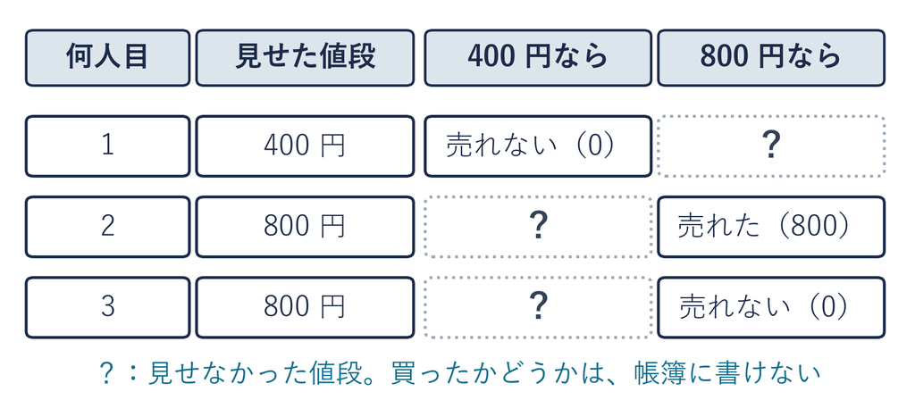

1人の客で分かるのは、見せた値段で売れたかどうかだけ

## バンディット・フィードバック

**バンディット・フィードバック**選んだほうの結果しか見えない記録

- **バンディット**：スロットマシンのこと。  
  レバー 1 本でお金を取るので「片腕の盗賊」
- **フィードバック**：やったことに返ってくる結果（当たり外れ・売れたか）
- **2 台のスロットマシン**：回せるのは 1 台。結果が返るのは回した台だけ
- **この店**：400 円と 800 円が 2 台のスロットマシン。  
  見せなかった値段の結果は分からない

選ばなかったほうは、記録に残らない

## 400 円で売れず 800 円で売れた後の選び方

トピック3 までの店長

決まりどおりに交互に見せるだけ

ここからの店長（平均だけで選ぶ店長）

帳簿を付けて、平均が高いほうを選び続ける

代役の名前は「平均だけで選ぶ店長」（私が作った）

**決まり**：それまでの平均が高いほうを見せる

**同じなら**：400 円を見せる

**最初の 2 人**：400 円の客は買わず、800 円の客は買った

**①** 400 円を何回も試す  
**②** 400 円をたまに試す  
**③** 400 円を二度と試さない

動画を止めて、①〜③から1つ選んで、少し考えてから再生

## 最初の 2 人の結果は 4 通り

店長の決まり

**最初の 2 人**：400 円と 800 円を 1 回ずつ見せる

**3 人目から**：それまでの平均が高いほうを見せる

**同じなら**：400 円を見せる

| 400 円の客 | 800 円の客 | 2 人の後の平均 | 3 人目から |
| --- | --- | --- | --- |
| ○ | ○ | 400 円・800 円 | 800 円を見せる。比べ続ける |
| ○ | × | 400 円・0 円 | ずっと 400 円 |
| × | ○ | 0 円・800 円 | ずっと 800 円 |
| × | × | 0 円・0 円 | 同じなので 400 円。ずっと 400 円 |

見せない値段は記録が増えない。だから平均も変わらない

○× と ×○ は、どちらが売れたかで値段が決まってしまう

## 平均だけで選ぶ店長の最初の6人

× ○ で始まった店（seed 15）を 6 人まで。決まりは前のページ

| 客 | 見せた値札 | 売れたか | 400 円の平均 | 800 円の平均 | 次の値札 |
| --- | --- | --- | --- | --- | --- |
| 1 | 400 | × | 0 | — | 800 |
| 2 | 800 | ○ | 0 | 800 | 800 |
| 3 | 800 | × | 0 | 400 | 800 |
| 4 | 800 | ○ | 0 | 約 533 | 800 |
| 5 | 800 | × | 0 | 400 | 800 |
| 6 | 800 | ○ | 0 | 480 | 800 |

同じ客で交互の試し売りなら：3 人目・5 人目にも 400 円。3 人目が買い、400 円の平均は約 133 円

800 円の平均は上下しても、400 円の 0 円より上。だから次はいつも 800 円

## seed 15：400 円に戻らない店長

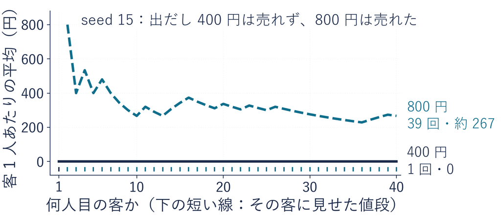

800 円の平均は 0 円より上のまま。400 円は二度と見せない

同じ客で交互の試し売りなら：売上の合計は 11600 円（この店長は 10400 円）

## 帳簿の数の 0 と期待値の 0 の違い

✕ よくある書き方

400 円は1回売れなかった  
だから 400 円の期待値は 0

○ 分けて書く

帳簿の数が 0（見せた回数 1）  
期待値は、まだ分からない

**帳簿の数**記録から計算した数（1 人の記録で当てた割合は 0 割）

**期待値**設定の割合から計算した数（400 円は 8 割なので 320 円）

1回の 0 は「売れない値段」の証拠にならない

## seed 42：出だしが普通なら

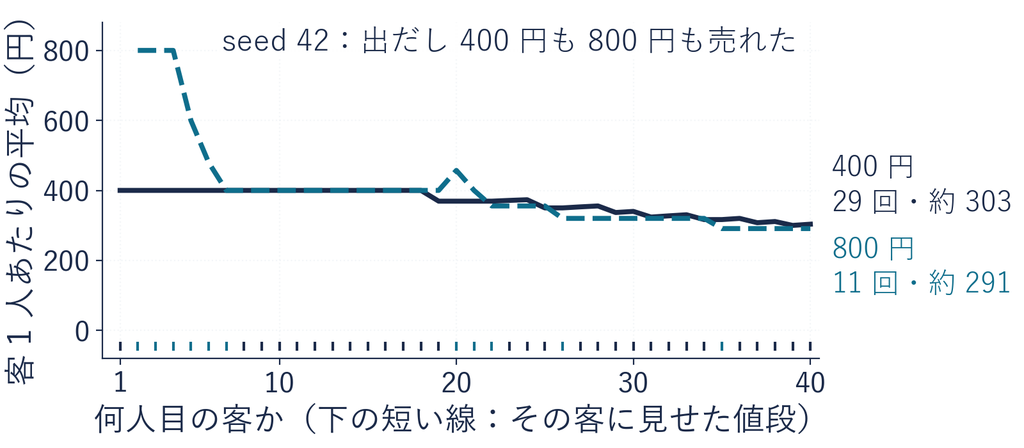

400 円は 29 回（約 303 円）、800 円は 11 回  
（約 291 円）。400 円を多く試せた

同じ客で交互の試し売りなら：売上の合計は 11200 円（この店長は 12000 円）

## 200本中 15 本：400 円を1回だけ試す店長

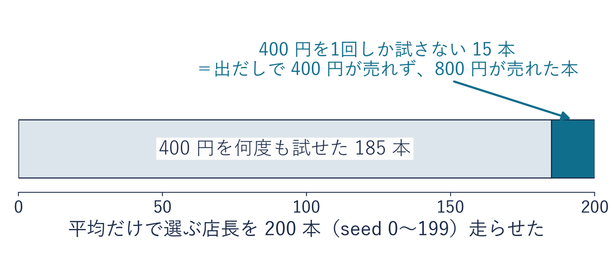

いつもではない。15 本では 400 円を最初の1回しか試さず、確かめ直せない

## 活用と探索

**よさそうな値段を見せるのが活用、別の値段を試すのが探索**

**活用**これまでの記録から、価値が最も高いと  
推定される行動（ここでは値段）を選ぶこと

**探索**推定の不確かな行動も選び  
その行動についての記録を増やすこと

- **多腕バンディット問題**：腕を選んで結果を見る、を繰り返す問題
- **腕**：スロットマシンのレバー。ここでは 400 円と 800 円の 2 本
- **平均だけで選ぶ店長**：活用だけで、探索しない

探索すれば得をするかは、あとで確かめる

## if・elif・else と += の読み方

```python
t, total, count = 2, [0, 800], [1, 1]   # 客 3 の前（p.56 の表）
if t < 2:
    a = t
elif total[1] / count[1] > total[0] / count[0]:
    a = 1
else:
    a = 0
print(a)                           # 1 が出る（値札 800）
```

| 行 | 店長の決まり（p.55） | 見せる値札 a |
| --- | --- | --- |
| 2-3 | **if**：最初の 2 人（t が 0 と 1）なら、1 回ずつ | 0 と 1 |
| 4-5 | **elif**：そうでなく、800 円の平均が上なら 800 円 | 1 |
| 6-7 | **else**：どれでもなければ 400 円（同じときも 400 円） | 0 |

`total[a] += PRICES[a] * sold` ＝ `total[a] = total[a] + PRICES[a] * sold`  
客 2（値段 800・売れた）なら、total[1] は 0 + 800 × 1 ＝ 800

※ 上から順に見て、最初に当てはまった所だけ動く・a は値段の番号（0 が 400 円で 1 が 800 円）

## 平均だけで選ぶ店長の関数の写経

```python
def greedy(seed, n=40):            # 平均だけで選ぶ店長
    rng = random.Random(seed)
    total, count = [0, 0], [0, 0]  # 値札ごとの売上合計と、見せた回数
    for t in range(n):
        if t < 2:
            a = t                  # 最初の2人：400 と 800 を1回ずつ
        elif total[1] / count[1] > total[0] / count[0]:
            a = 1                  # 800 の平均が上なら 800
        else:
            a = 0                  # そうでなければ 400（同じなら 400）
        sold = visit(a, rng)       # 値札 a（0＝400、1＝800）で客を1人
        total[a] += PRICES[a] * sold   # += ＝ 今の値に足し込む
        count[a] += 1
    return total, count
```

| 行 | 部品 | 中身 |
| --- | --- | --- |
| 1-3 | **① 名前と帳簿** | greedy＝英語で「欲ばり」（代役の名前）・seed・人数 n |
| 4-10 | **② 客ごとに選ぶ** | elif の行で、2 つの平均（合計 ÷ 回数）を比べる |
| 11-13 | **③ 売上を足す** | 売れたか（1・0）を見て、+= で足し込む |
| 14 | **④ 返す** | 売上合計 total と回数 count |

## 2 つの店の写経

```python
for seed in [15, 42]:              # p.57 と p.59 の 2 つの店
    total, count = greedy(seed, n=40)   # n ＝ 客の人数
    for a in [0, 1]:
        print("seed", seed, " 値札", PRICES[a], " 見せた:", count[a],
              "回  平均:", round(total[a] / count[a]))
```

| 行 | 部品 | 渡すもの | 返ってくるもの・起きること |
| --- | --- | --- | --- |
| 1 | **① seed を順に** | `[15, 42]` | seed に 15 と 42 が入る |
| 2 | **② 店長を動かす** | seed と `n=40` | 売上合計 total と回数 count |
| 3-5 | **③ 表示** | 値段 400・800 の順 | 見せた回数と平均 |

※ `total[a] / count[a]` は客 1 人あたりの平均（売上合計 ÷ 見せた回数）。`round(…)` で円の整数に

**STEP 1** **＋ コード**でセルを 2 つ足し、  
前のページの関数とこの 5 行を写して実行 **STEP 2** 平均の 0 と 303 を探す

⏸ PAUSE 止めて Colab で写して実行（目安 5 分）。4 行が出たら再生に戻る

## 演習4 客の人数の書き換え

p.64 の出力 seed 15 の値札 400 は 1 回・0

演習 4

100 人でも 400 円に戻らないかを確かめる

```python
for seed in [15, 42]:              # p.57 と p.59 の 2 つの店
    total, count = greedy(seed, n=40)   # ← ここを書き換える
    for a in [0, 1]:
        print("seed", seed, " 値札", PRICES[a], " 見せた:", count[a],
              "回  平均:", round(total[a] / count[a]))
```

1. **書き換える**：写経のセルは残し、**＋ コード**で足したセルに  
   同じ 5 行を写して、2 行目を `n=100` に
2. **確かめる**：p.57 の「400 円は二度と見せない」が、100 人でも本当か
3. **終わり**：4 行が出て、自分が店長なら次に試す値段と理由を一文書いたら

一文は小課題ノートの段 4 に（「帳簿の数が 0」と「まだ分からない」を分ける）

⏸ PAUSE 動画を止めて $3$ 分。4 行と一文ができたら再生に戻る

## 演習4の答え

| 店 | 客の人数 | 400 円の回数 | 400 円の平均 | 800 円の回数 | 800 円の平均 |
| --- | --- | --- | --- | --- | --- |
| seed 15 | 40（p.64） | 1 | 0 | 39 | 267 |
| seed 15 | 100 | 1 | 0 | 99 | 234 |
| seed 42 | 40（p.64） | 29 | 303 | 11 | 291 |
| seed 42 | 100 | 89 | 319 | 11 | 291 |

- **確かめた結果**：戻らない。100 人でも 400 円は 1 回のまま
- **理由**：800 円の平均は 234 円まで下がっても、400 円の 0 円より上
- **seed 42 も**：800 円は 11 回のまま。選ばない値段は記録が増えない
- **一文の例**：400 円を試す。1 回の 0 では判断できない

選ばなかった値段は、選び直さないと確かめられない

※ 配布のデモ（lecture09_greedy_demo.html）で、seed 15 と 42 の店長を自分でも動かせる

## 世の中での使われ方

同じ形の場面

**ネット広告**：クリックの記録から広告を選ぶ

**おすすめ表示**：買われた記録から商品を並べる

**試し売り**：客ごとに値段を分ける（A/B テスト）  
値段以外の条件はそろえて比べる

試し売りの記録から買う割合を当てる（トピック3 の最尤推定）  
→ 計算機の店に入れて本物の店に合わせる（前半のキャリブレーション）

やること：小課題ノートを上から実行して、manaba の「第9回 小課題」に提出する

## まとめ

疑問 帳簿の数の高いほうだけ見せてよいか

回答 帳簿の数の高いほうを見せていくと、多くの記録で 400 円を  
選ぶようになった。でも初めに低く当たった値段は  
見せないので、当て直されないことがある

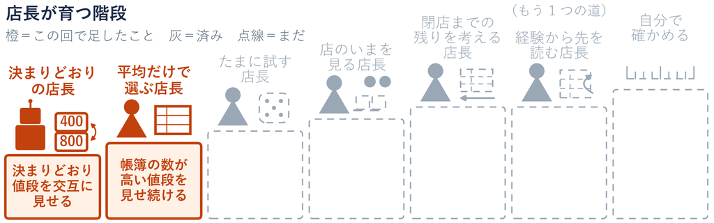

**1 回では決めない。0 も数える**

## 今日の 4 つの疑問と回答

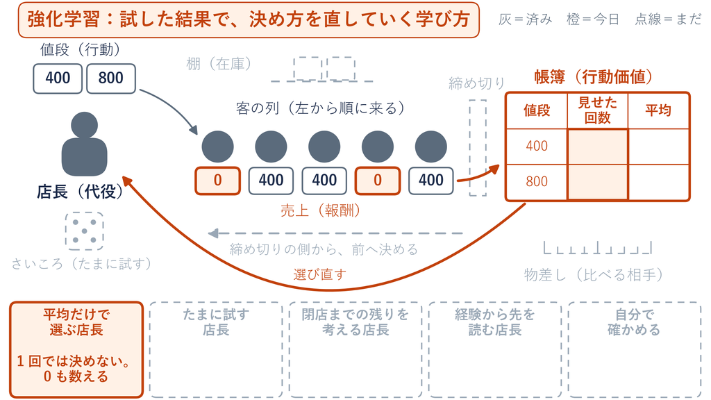

|  | 疑問 | 回答 |
| --- | --- | --- |
| T1 | 1 回売れた値段で、次も決めてよいか | まだ決められない。売れるかは割合と運で決まる。 何を数えるか（売上）を先に決める |
| T2 | 20 人の記録だけで、800 円に決めてよいか | 決められない。有利な値段は期待値で決まり、 短い記録の売上は入れ替わる。記録を伸ばしてから決める |
| T3 | 割合を知らないとき、記録からどう当てるか | 記録がいちばん出やすくなる割合を答えにする（最尤推定）。 帳簿の数 ＝ 当てた割合 × 値段 |
| T4 | 帳簿の数の高いほうだけ見せてよいか | 多くの記録で 400 円を選ぶようになった。 でも初めに低く当たった値段は、当て直されないことがある |

**1 回では決めない。0 も数える**